# Predict Bike Sharing Demand with AutoGluon Template

## Project: Predict Bike Sharing Demand with AutoGluon

This notebook is a template with each step that you need to complete for the project.

Please fill in your code where there are explicit `?` markers in the notebook. You are welcome to add more cells and code as you see fit.

Once you have completed all the code implementations, please export your notebook as a HTML file so the reviews can view your code. Make sure you have all outputs correctly outputted.

`File-> Export Notebook As... -> Export Notebook as HTML`

There is a writeup to complete as well after all code implememtation is done. Please answer all questions and attach the necessary tables and charts. You can complete the writeup in either markdown or PDF.

Completing the code template and writeup template will cover all of the rubric points for this project.

The rubric contains "Stand Out Suggestions" for enhancing the project beyond the minimum requirements. The stand out suggestions are optional. If you decide to pursue the "stand out suggestions", you can include the code in this notebook and also discuss the results in the writeup file.

## Step 1: Create an account with Kaggle

### Create Kaggle Account and download API key

Below is example of steps to get the API username and key. Each student will have their own username and key.

1. Open account settings.

2. Scroll down to API and click Create New API Token.

3. Open up `kaggle.json` and use the username and key.


## Step 2: Download the Kaggle dataset using the kaggle python library

### Open up Sagemaker Studio and use starter template

1. Notebook should be using a `ml.t3.medium` instance (2 vCPU + 4 GiB)
2. Notebook should be using kernal: `Python 3 (MXNet 1.8 Python 3.7 CPU Optimized)`

### Install packages

```python
!pip install -U pip
!pip install -U setuptools wheel
!pip install -U "mxnet<2.0.0" bokeh==2.0.1
!pip install autogluon --no-cache-dir
# Without --no-cache-dir, smaller aws instances may have trouble installing
```

[output not shown]

[output not shown]

[output not shown]

[output not shown]

[output not shown]

[output not shown]

[output cut: 238 more lines]

[output not shown]

[output not shown]

[output not shown]

### Setup Kaggle API Key

```python
# create the .kaggle directory and an empty kaggle.json file
'''!pip install -q Kaggle
!mkdir -p /root/.kaggle
!touch /root/.kaggle/kaggle.json
!chmod 600 /root/.kaggle/kaggle.json
!kaggle competitions download -c bike-sharing-demand'''

# Install Kaggle API client
%pip install kaggle
from os import path
!mkdir .kaggle
!echo {} > .kaggle/kaggle.json
!copy path\C:\Users\utkut\.kaggle
!kaggle competitions download -c bike-sharing-demand
```

```
A subdirectory or file .kaggle already exists.
```

[output not shown]

[output not shown]

```
bike-sharing-demand.zip: Skipping, found more recently modified local copy (use --force to force download)
```

```python
# Fill in your user name and key from creating the kaggle account and API token file
'''import json
kaggle_username = "kemalutkukosman"
kaggle_key = "20018774a99c509dee245a5c7f218a91"

# Save API token the kaggle.json file
with open("C:\Users\utkut\.kaggle\kaggle.json", "w") as f:
    f.write(json.dumps({"username": kaggle_username, "key": kaggle_key}))'''
```

### Download and explore dataset

### Go to the bike sharing demand competition and agree to the terms

```python
# Download the dataset, it will be in a .zip file so you'll need to unzip it as well.
!kaggle competitions download -c bike-sharing-demand
# If you already downloaded it you can use the -o command to overwrite the file
!unzip -o bike-sharing-demand.zip
```

```
bike-sharing-demand.zip: Skipping, found more recently modified local copy (use --force to force download)
```

[output not shown]

```python
import pandas as pd
from autogluon.tabular import TabularPredictor
```

```python
# Create the train dataset in pandas by reading the csv
# Set the parsing of the datetime column so you can use some of the `dt` features in pandas later
train = pd.read_csv('train.csv', parse_dates=['datetime'])
train.head()
```

|  | datetime | season | holiday | workingday | weather | temp | atemp | humidity | windspeed | casual | registered | count |
| --- | --- | --- | --- | --- | --- | --- | --- | --- | --- | --- | --- | --- |
| 0 | 2011-01-01 00:00:00 | 1 | 0 | 0 | 1 | 9.84 | 14.395 | 81 | 0.0 | 3 | 13 | 16 |
| 1 | 2011-01-01 01:00:00 | 1 | 0 | 0 | 1 | 9.02 | 13.635 | 80 | 0.0 | 8 | 32 | 40 |
| 2 | 2011-01-01 02:00:00 | 1 | 0 | 0 | 1 | 9.02 | 13.635 | 80 | 0.0 | 5 | 27 | 32 |
| 3 | 2011-01-01 03:00:00 | 1 | 0 | 0 | 1 | 9.84 | 14.395 | 75 | 0.0 | 3 | 10 | 13 |
| 4 | 2011-01-01 04:00:00 | 1 | 0 | 0 | 1 | 9.84 | 14.395 | 75 | 0.0 | 0 | 1 | 1 |

```python
train.describe()
```

|  | datetime | season | holiday | workingday | weather | temp | atemp | humidity | windspeed | casual | registered | count |
| --- | --- | --- | --- | --- | --- | --- | --- | --- | --- | --- | --- | --- |
| count | 10886 | 10886.000000 | 10886.000000 | 10886.000000 | 10886.000000 | 10886.00000 | 10886.000000 | 10886.000000 | 10886.000000 | 10886.000000 | 10886.000000 | 10886.000000 |
| mean | 2011-12-27 05:56:22.399411968 | 2.506614 | 0.028569 | 0.680875 | 1.418427 | 20.23086 | 23.655084 | 61.886460 | 12.799395 | 36.021955 | 155.552177 | 191.574132 |
| min | 2011-01-01 00:00:00 | 1.000000 | 0.000000 | 0.000000 | 1.000000 | 0.82000 | 0.760000 | 0.000000 | 0.000000 | 0.000000 | 0.000000 | 1.000000 |
| 25% | 2011-07-02 07:15:00 | 2.000000 | 0.000000 | 0.000000 | 1.000000 | 13.94000 | 16.665000 | 47.000000 | 7.001500 | 4.000000 | 36.000000 | 42.000000 |
| 50% | 2012-01-01 20:30:00 | 3.000000 | 0.000000 | 1.000000 | 1.000000 | 20.50000 | 24.240000 | 62.000000 | 12.998000 | 17.000000 | 118.000000 | 145.000000 |
| 75% | 2012-07-01 12:45:00 | 4.000000 | 0.000000 | 1.000000 | 2.000000 | 26.24000 | 31.060000 | 77.000000 | 16.997900 | 49.000000 | 222.000000 | 284.000000 |
| max | 2012-12-19 23:00:00 | 4.000000 | 1.000000 | 1.000000 | 4.000000 | 41.00000 | 45.455000 | 100.000000 | 56.996900 | 367.000000 | 886.000000 | 977.000000 |
| std | NaN | 1.116174 | 0.166599 | 0.466159 | 0.633839 | 7.79159 | 8.474601 | 19.245033 | 8.164537 | 49.960477 | 151.039033 | 181.144454 |

```python
train.info()
```

```
<class 'pandas.core.frame.DataFrame'>
RangeIndex: 10886 entries, 0 to 10885
Data columns (total 12 columns):
 #   Column      Non-Null Count  Dtype
---  ------      --------------  -----
 0   datetime    10886 non-null  datetime64[ns]
 1   season      10886 non-null  int64
 2   holiday     10886 non-null  int64
 3   workingday  10886 non-null  int64
 4   weather     10886 non-null  int64
 5   temp        10886 non-null  float64
 6   atemp       10886 non-null  float64
 7   humidity    10886 non-null  int64
 8   windspeed   10886 non-null  float64
 9   casual      10886 non-null  int64
 10  registered  10886 non-null  int64
 11  count       10886 non-null  int64
dtypes: datetime64[ns](1), float64(3), int64(8)
memory usage: 1020.7 KB
```

```python
# Create the test pandas dataframe in pandas by reading the csv, remember to parse the datetime!
test = pd.read_csv('test.csv', parse_dates= ['datetime'])
test.head()
```

|  | datetime | season | holiday | workingday | weather | temp | atemp | humidity | windspeed |
| --- | --- | --- | --- | --- | --- | --- | --- | --- | --- |
| 0 | 2011-01-20 00:00:00 | 1 | 0 | 1 | 1 | 10.66 | 11.365 | 56 | 26.0027 |
| 1 | 2011-01-20 01:00:00 | 1 | 0 | 1 | 1 | 10.66 | 13.635 | 56 | 0.0000 |
| 2 | 2011-01-20 02:00:00 | 1 | 0 | 1 | 1 | 10.66 | 13.635 | 56 | 0.0000 |
| 3 | 2011-01-20 03:00:00 | 1 | 0 | 1 | 1 | 10.66 | 12.880 | 56 | 11.0014 |
| 4 | 2011-01-20 04:00:00 | 1 | 0 | 1 | 1 | 10.66 | 12.880 | 56 | 11.0014 |

```python
# Same thing as train and test dataset
submission = pd.read_csv('sampleSubmission.csv', parse_dates=['datetime'])
submission.head()
```

|  | datetime | count |
| --- | --- | --- |
| 0 | 2011-01-20 00:00:00 | 0 |
| 1 | 2011-01-20 01:00:00 | 0 |
| 2 | 2011-01-20 02:00:00 | 0 |
| 3 | 2011-01-20 03:00:00 | 0 |
| 4 | 2011-01-20 04:00:00 | 0 |

## Step 3: Train a model using AutoGluon’s Tabular Prediction

Requirements:

- We are prediting `count`, so it is the label we are setting.
- Ignore `casual` and `registered` columns as they are also not present in the test dataset.
- Use the `root_mean_squared_error` as the metric to use for evaluation.
- Set a time limit of 10 minutes (600 seconds).
- Use the preset `best_quality` to focus on creating the best model.

```python
dtrain = train.drop(['casual', 'registered'], axis=1)
dtrain.head()
```

|  | datetime | season | holiday | workingday | weather | temp | atemp | humidity | windspeed | count |
| --- | --- | --- | --- | --- | --- | --- | --- | --- | --- | --- |
| 0 | 2011-01-01 00:00:00 | 1 | 0 | 0 | 1 | 9.84 | 14.395 | 81 | 0.0 | 16 |
| 1 | 2011-01-01 01:00:00 | 1 | 0 | 0 | 1 | 9.02 | 13.635 | 80 | 0.0 | 40 |
| 2 | 2011-01-01 02:00:00 | 1 | 0 | 0 | 1 | 9.02 | 13.635 | 80 | 0.0 | 32 |
| 3 | 2011-01-01 03:00:00 | 1 | 0 | 0 | 1 | 9.84 | 14.395 | 75 | 0.0 | 13 |
| 4 | 2011-01-01 04:00:00 | 1 | 0 | 0 | 1 | 9.84 | 14.395 | 75 | 0.0 | 1 |

```python
predictor = TabularPredictor(label = 'count',eval_metric='rmse').fit(train_data = dtrain,
                                                                    time_limit = 600,
                                                                    presets = 'best_quality')
```

[output not shown]

[output cut: 133 more lines]

```
	-54.9694	 = Validation score   (-root_mean_squared_error)
	3.74s	 = Training   runtime
	0.11s	 = Validation runtime
Fitting model: NeuralNetTorch_BAG_L2 ... Training model for up to 8.78s of the 8.7s of remaining time.
	Fitting 8 child models (S1F1 - S1F8) | Fitting with ParallelLocalFoldFittingStrategy (8 workers, per: cpus=2, gpus=0, memory=0.19%)
	-82.5867	 = Validation score   (-root_mean_squared_error)
	11.78s	 = Training   runtime
	0.19s	 = Validation runtime
Fitting model: WeightedEnsemble_L3 ... Training model for up to 360.0s of the -11.27s of remaining time.
	Ensemble Weights: {'NeuralNetFastAI_BAG_L2': 0.591, 'RandomForestMSE_BAG_L2': 0.273, 'ExtraTreesMSE_BAG_L2': 0.136}
	-50.5467	 = Validation score   (-root_mean_squared_error)
	0.07s	 = Training   runtime
	0.0s	 = Validation runtime
AutoGluon training complete, total runtime = 412.39s ... Best model: "WeightedEnsemble_L3"
TabularPredictor saved. To load, use: predictor = TabularPredictor.load("AutogluonModels\ag-20240501_195123")
```

### Review AutoGluon's training run with ranking of models that did the best.

```python
predictor.fit_summary()
```

```
*** Summary of fit() ***
Estimated performance of each model:
                     model   score_val              eval_metric  pred_time_val    fit_time  pred_time_val_marginal  fit_time_marginal  stack_level  can_infer  fit_order
0      WeightedEnsemble_L3  -50.546678  root_mean_squared_error       8.256409  269.496783                0.001001           0.065149            3       True         21
1   NeuralNetFastAI_BAG_L2  -51.681651  root_mean_squared_error       7.240595  260.902925                0.263320          28.041399            2       True         18
2   RandomForestMSE_BAG_L2  -53.308067  root_mean_squared_error       7.493336  239.981912                0.516061           7.120385            2       True         15
3     ExtraTreesMSE_BAG_L2  -53.910722  root_mean_squared_error       7.476027  234.269849                0.498753           1.408323            2       True         17
4          LightGBM_BAG_L2  -54.582702  root_mean_squared_error       7.126593  237.041662                0.149318           4.180136            2       True         14
5           XGBoost_BAG_L2  -54.969406  root_mean_squared_error       7.090932  236.602991                0.113657           3.741464            2       True         19
6          CatBoost_BAG_L2  -55.419480  root_mean_squared_error       7.005540  256.235006                0.028265          23.373480            2       True         16
7        LightGBMXT_BAG_L2  -60.108328  root_mean_squared_error       8.534640  245.706263                1.557365          12.844737            2       True         13
8    NeuralNetTorch_BAG_L2  -82.586739  root_mean_squared_error       7.170660  244.644044                0.193385          11.782517            2       True         20
9    KNeighborsDist_BAG_L1  -84.146423  root_mean_squared_error       0.032151    0.045907                0.032151           0.045907            1       True          2
10     WeightedEnsemble_L2  -84.146423  root_mean_squared_error       0.033151    0.114164                0.001000           0.068257            2       True         12
11   KNeighborsUnif_BAG_L1 -101.588176  root_mean_squared_error       0.024882    0.050975                0.024882           0.050975            1       True          1
12  RandomForestMSE_BAG_L1 -116.552091  root_mean_squared_error       0.491585    2.042678                0.491585           2.042678            1       True          5
13    ExtraTreesMSE_BAG_L1 -124.602302  root_mean_squared_error       0.525373    0.795767                0.525373           0.795767            1       True          7
14    LightGBMLarge_BAG_L1 -130.425007  root_mean_squared_error       0.235689    4.164733                0.235689           4.164733            1       True         11
15         CatBoost_BAG_L1 -130.461205  root_mean_squared_error       0.046095  133.073725                0.046095         133.073725            1       True          6
16         LightGBM_BAG_L1 -131.054162  root_mean_squared_error       0.576338    5.673325                0.576338           5.673325            1       True          4
17       LightGBMXT_BAG_L1 -131.460909  root_mean_squared_error       4.515744   14.758985                4.515744          14.758985            1       True          3
18          XGBoost_BAG_L1 -131.893935  root_mean_squared_error       0.170651    2.462430                0.170651           2.462430            1       True          9
19  NeuralNetFastAI_BAG_L1 -135.961800  root_mean_squared_error       0.216314   20.114915                0.216314          20.114915            1       True          8
20   NeuralNetTorch_BAG_L1 -140.091259  root_mean_squared_error       0.142453   49.678085                0.142453          49.678085            1       True         10
Number of models trained: 21
Types of models trained:
{'StackerEnsembleModel_TabularNeuralNetTorch', 'StackerEnsembleModel_XT', 'StackerEnsembleModel_LGB', 'StackerEnsembleModel_XGBoost', 'WeightedEnsembleModel', 'StackerEnsembleModel_CatBoost', 'StackerEnsembleModel_RF', 'StackerEnsembleModel_NNFastAiTabular', 'StackerEnsembleModel_KNN'}
Bagging used: True  (with 8 folds)
Multi-layer stack-ensembling used: True  (with 3 levels)
Feature Metadata (Processed):
(raw dtype, special dtypes):
('float', [])                : 3 | ['temp', 'atemp', 'windspeed']
('int', [])                  : 3 | ['season', 'weather', 'humidity']
('int', ['bool'])            : 2 | ['holiday', 'workingday']
('int', ['datetime_as_int']) : 5 | ['datetime', 'datetime.year', 'datetime.month', 'datetime.day', 'datetime.dayofweek']
Plot summary of models saved to file: AutogluonModels\ag-20240501_195123SummaryOfModels.html
*** End of fit() summary ***
```

[output not shown]

[output cut: 211 more lines]

[output not shown]

### Create predictions from test dataset

```python
predictions = predictor.predict(test)
predictions.head()
```

```
0    24.279644
1    40.929688
2    45.278423
3    47.630032
4    49.638954
Name: count, dtype: float32
```

#### NOTE: Kaggle will reject the submission if we don't set everything to be > 0.

```python
# Describe the `predictions` series to see if there are any negative values
predictions.describe()
```

```
count    6493.000000
mean      100.986916
std        88.837456
min         2.015530
25%        23.209354
50%        68.169060
75%       168.482269
max       355.175720
Name: count, dtype: float64
```

```python
# How many negative values do we have?
negative_value_counts = (predictions < 0).sum()
print('Total number of negative values: {} '.format(negative_value_counts))
```

```
Total number of negative values: 0
```

```python
# Set them to zero
predictions[predictions < 0] = 0
```

### Set predictions to submission dataframe, save, and submit

```python
submission["count"] = predictions
submission.to_csv("submission.csv", index=False)
```

```python
leaderboard_df = pd.DataFrame(predictor.leaderboard(silent=True))
leaderboard_df
```

|  | model | score_val | eval_metric | pred_time_val | fit_time | pred_time_val_marginal | fit_time_marginal | stack_level | can_infer | fit_order |
| --- | --- | --- | --- | --- | --- | --- | --- | --- | --- | --- |
| 0 | WeightedEnsemble_L3 | -50.546678 | root_mean_squared_error | 8.256409 | 269.496783 | 0.001001 | 0.065149 | 3 | True | 21 |
| 1 | NeuralNetFastAI_BAG_L2 | -51.681651 | root_mean_squared_error | 7.240595 | 260.902925 | 0.263320 | 28.041399 | 2 | True | 18 |
| 2 | RandomForestMSE_BAG_L2 | -53.308067 | root_mean_squared_error | 7.493336 | 239.981912 | 0.516061 | 7.120385 | 2 | True | 15 |
| 3 | ExtraTreesMSE_BAG_L2 | -53.910722 | root_mean_squared_error | 7.476027 | 234.269849 | 0.498753 | 1.408323 | 2 | True | 17 |
| 4 | LightGBM_BAG_L2 | -54.582702 | root_mean_squared_error | 7.126593 | 237.041662 | 0.149318 | 4.180136 | 2 | True | 14 |
| 5 | XGBoost_BAG_L2 | -54.969406 | root_mean_squared_error | 7.090932 | 236.602991 | 0.113657 | 3.741464 | 2 | True | 19 |
| 6 | CatBoost_BAG_L2 | -55.419480 | root_mean_squared_error | 7.005540 | 256.235006 | 0.028265 | 23.373480 | 2 | True | 16 |
| 7 | LightGBMXT_BAG_L2 | -60.108328 | root_mean_squared_error | 8.534640 | 245.706263 | 1.557365 | 12.844737 | 2 | True | 13 |
| 8 | NeuralNetTorch_BAG_L2 | -82.586739 | root_mean_squared_error | 7.170660 | 244.644044 | 0.193385 | 11.782517 | 2 | True | 20 |
| 9 | KNeighborsDist_BAG_L1 | -84.146423 | root_mean_squared_error | 0.032151 | 0.045907 | 0.032151 | 0.045907 | 1 | True | 2 |
| 10 | WeightedEnsemble_L2 | -84.146423 | root_mean_squared_error | 0.033151 | 0.114164 | 0.001000 | 0.068257 | 2 | True | 12 |
| 11 | KNeighborsUnif_BAG_L1 | -101.588176 | root_mean_squared_error | 0.024882 | 0.050975 | 0.024882 | 0.050975 | 1 | True | 1 |
| 12 | RandomForestMSE_BAG_L1 | -116.552091 | root_mean_squared_error | 0.491585 | 2.042678 | 0.491585 | 2.042678 | 1 | True | 5 |
| 13 | ExtraTreesMSE_BAG_L1 | -124.602302 | root_mean_squared_error | 0.525373 | 0.795767 | 0.525373 | 0.795767 | 1 | True | 7 |
| 14 | LightGBMLarge_BAG_L1 | -130.425007 | root_mean_squared_error | 0.235689 | 4.164733 | 0.235689 | 4.164733 | 1 | True | 11 |
| 15 | CatBoost_BAG_L1 | -130.461205 | root_mean_squared_error | 0.046095 | 133.073725 | 0.046095 | 133.073725 | 1 | True | 6 |
| 16 | LightGBM_BAG_L1 | -131.054162 | root_mean_squared_error | 0.576338 | 5.673325 | 0.576338 | 5.673325 | 1 | True | 4 |
| 17 | LightGBMXT_BAG_L1 | -131.460909 | root_mean_squared_error | 4.515744 | 14.758985 | 4.515744 | 14.758985 | 1 | True | 3 |
| 18 | XGBoost_BAG_L1 | -131.893935 | root_mean_squared_error | 0.170651 | 2.462430 | 0.170651 | 2.462430 | 1 | True | 9 |
| 19 | NeuralNetFastAI_BAG_L1 | -135.961800 | root_mean_squared_error | 0.216314 | 20.114915 | 0.216314 | 20.114915 | 1 | True | 8 |
| 20 | NeuralNetTorch_BAG_L1 | -140.091259 | root_mean_squared_error | 0.142453 | 49.678085 | 0.142453 | 49.678085 | 1 | True | 10 |

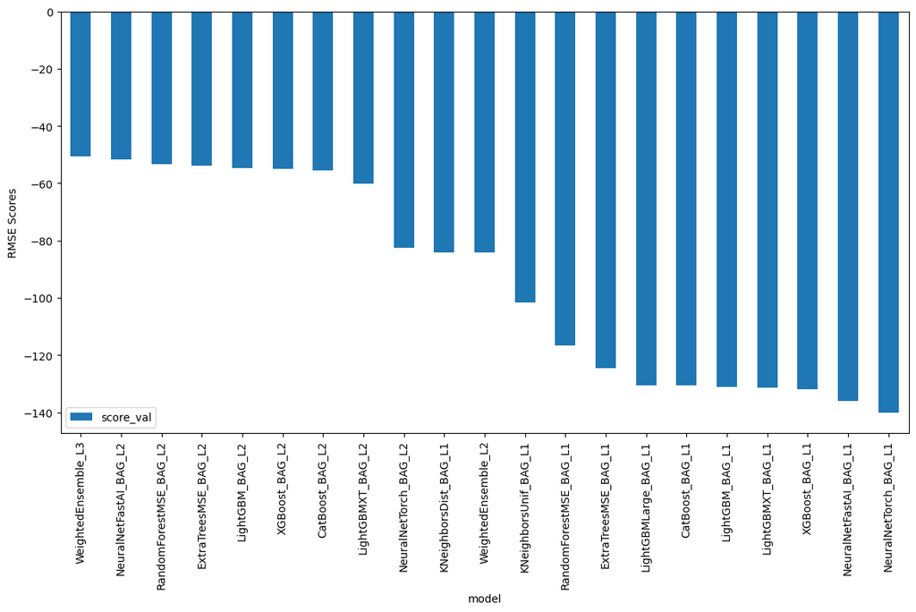

```python
import matplotlib.pyplot as plt
leaderboard = predictor.leaderboard()
leaderboard.plot(kind="bar", x="model", y="score_val", figsize=(14, 7))
plt.ylabel("RMSE Scores")
plt.show()
```

```python
!kaggle competitions submit -c bike-sharing-demand -f submission.csv -m "first raw submission"
```

```
Successfully submitted to Bike Sharing Demand
```

#### View submission via the command line or in the web browser under the competition's page - `My Submissions`

```python
!kaggle competitions submissions -c bike-sharing-demand
```

[output not shown]

## Step 4: Exploratory Data Analysis and Creating an additional feature

- Any additional feature will do, but a great suggestion would be to separate out the datetime into hour, day, or month parts.

```
array([[<Axes: title={'center': 'datetime'}>,
        <Axes: title={'center': 'season'}>,
        <Axes: title={'center': 'holiday'}>],
       [<Axes: title={'center': 'workingday'}>,
        <Axes: title={'center': 'weather'}>,
        <Axes: title={'center': 'temp'}>],
       [<Axes: title={'center': 'atemp'}>,
        <Axes: title={'center': 'humidity'}>,
        <Axes: title={'center': 'windspeed'}>],
       [<Axes: title={'center': 'count'}>, <Axes: >, <Axes: >]],
      dtype=object)
```

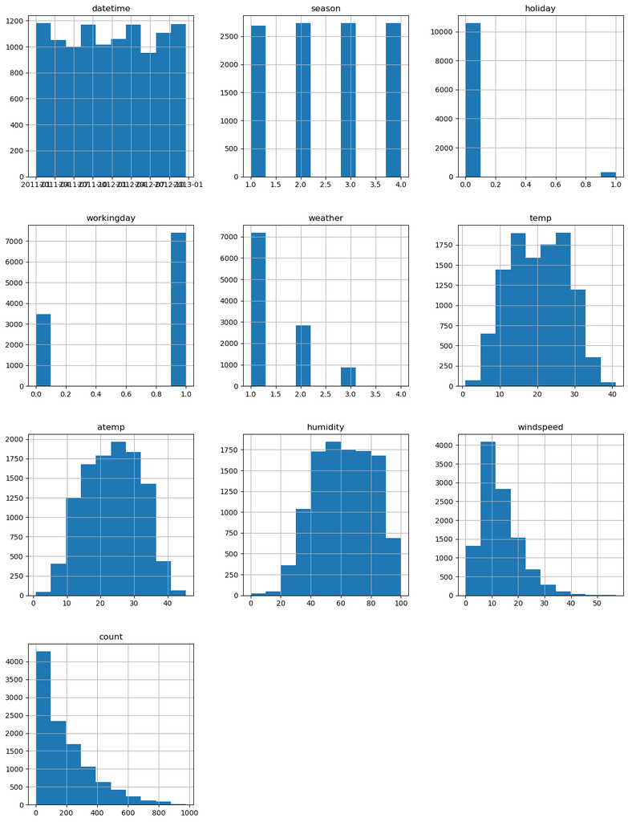

```python
# Create a histogram of all features to show the distribution of each one relative to the data. This is part of the exploritory data analysis
dtrain.hist(figsize = (15,20))
```

```python
# create a new feature
'''print(train.columns.tolist())
print(test.columns.tolist())'''

dtrain['hour'] = dtrain['datetime'].dt.hour
test['hour'] = test['datetime'].dt.hour
```

## Make category types for these so models know they are not just numbers

- AutoGluon originally sees these as ints, but in reality they are int representations of a category.
- Setting the dtype to category will classify these as categories in AutoGluon.

```python
dtrain["season"] = dtrain['season'].astype('category')
dtrain["weather"] = dtrain['weather'].astype('category')
dtrain['hour'] = dtrain['hour'].astype('category')
test["season"] = test['season'].astype('category')
test["weather"] = test['weather'].astype('category')
test['hour'] = test['hour'].astype('category')
```

```python
# View are new feature
dtrain.head()
```

|  | datetime | season | holiday | workingday | weather | temp | atemp | humidity | windspeed | count | hour |
| --- | --- | --- | --- | --- | --- | --- | --- | --- | --- | --- | --- |
| 0 | 2011-01-01 00:00:00 | 1 | 0 | 0 | 1 | 9.84 | 14.395 | 81 | 0.0 | 16 | 0 |
| 1 | 2011-01-01 01:00:00 | 1 | 0 | 0 | 1 | 9.02 | 13.635 | 80 | 0.0 | 40 | 1 |
| 2 | 2011-01-01 02:00:00 | 1 | 0 | 0 | 1 | 9.02 | 13.635 | 80 | 0.0 | 32 | 2 |
| 3 | 2011-01-01 03:00:00 | 1 | 0 | 0 | 1 | 9.84 | 14.395 | 75 | 0.0 | 13 | 3 |
| 4 | 2011-01-01 04:00:00 | 1 | 0 | 0 | 1 | 9.84 | 14.395 | 75 | 0.0 | 1 | 4 |

```
array([[<Axes: title={'center': 'datetime'}>,
        <Axes: title={'center': 'holiday'}>,
        <Axes: title={'center': 'workingday'}>],
       [<Axes: title={'center': 'temp'}>,
        <Axes: title={'center': 'atemp'}>,
        <Axes: title={'center': 'humidity'}>],
       [<Axes: title={'center': 'windspeed'}>,
        <Axes: title={'center': 'count'}>, <Axes: >]], dtype=object)
```

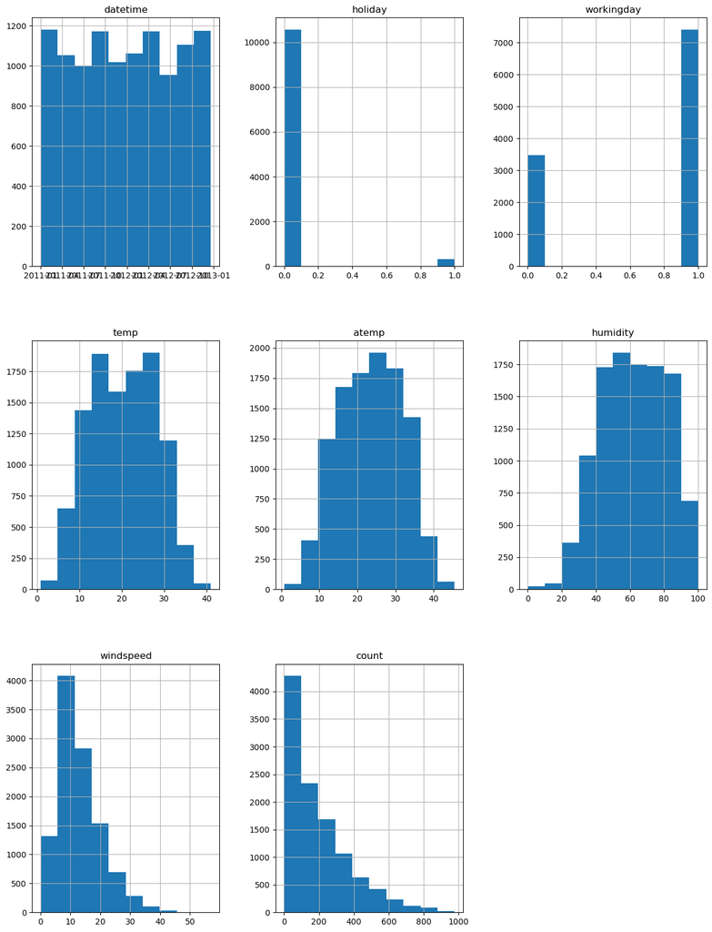

```python
# View histogram of all features again now with the hour feature
dtrain.hist(figsize = (15,20))
```

## Step 5: Rerun the model with the same settings as before, just with more features

```python
predictor_new_features = TabularPredictor(label = 'count', eval_metric='rmse',).fit(train_data = dtrain,
                                                                                     time_limit=600,
                                                                                     presets = 'best_quality')
```

[output not shown]

[output cut: 113 more lines]

```
	-32.6141	 = Validation score   (-root_mean_squared_error)
	2.37s	 = Training   runtime
	0.67s	 = Validation runtime
Fitting model: NeuralNetFastAI_BAG_L2 ... Training model for up to 11.17s of the 11.11s of remaining time.
	Fitting 8 child models (S1F1 - S1F8) | Fitting with ParallelLocalFoldFittingStrategy (8 workers, per: cpus=2, gpus=0, memory=0.27%)
	-30.3963	 = Validation score   (-root_mean_squared_error)
	16.54s	 = Training   runtime
	0.34s	 = Validation runtime
Fitting model: WeightedEnsemble_L3 ... Training model for up to 360.0s of the -12.93s of remaining time.
	Ensemble Weights: {'NeuralNetFastAI_BAG_L2': 0.4, 'LightGBM_BAG_L2': 0.32, 'LightGBMXT_BAG_L2': 0.24, 'CatBoost_BAG_L2': 0.04}
	-29.6383	 = Validation score   (-root_mean_squared_error)
	0.07s	 = Training   runtime
	0.0s	 = Validation runtime
AutoGluon training complete, total runtime = 442.06s ... Best model: "WeightedEnsemble_L3"
TabularPredictor saved. To load, use: predictor = TabularPredictor.load("AutogluonModels\ag-20240501_201244")
```

```python
predictor_new_features.fit_summary()
```

```
*** Summary of fit() ***
Estimated performance of each model:
                     model   score_val              eval_metric  pred_time_val    fit_time  pred_time_val_marginal  fit_time_marginal  stack_level  can_infer  fit_order
0      WeightedEnsemble_L3  -29.638262  root_mean_squared_error       7.377089  369.398943                0.000997           0.074600            3       True         17
1   NeuralNetFastAI_BAG_L2  -30.396338  root_mean_squared_error       6.453931  273.668264                0.344243          16.543141            2       True         16
2          LightGBM_BAG_L2  -30.409617  root_mean_squared_error       6.377668  263.373397                0.267980           6.248274            2       True         12
3        LightGBMXT_BAG_L2  -30.496854  root_mean_squared_error       6.698429  264.636369                0.588741           7.511246            2       True         11
4          CatBoost_BAG_L2  -30.744497  root_mean_squared_error       6.175129  339.021682                0.065441          81.896559            2       True         14
5     ExtraTreesMSE_BAG_L2  -32.614105  root_mean_squared_error       6.781365  259.493640                0.671677           2.368517            2       True         15
6   RandomForestMSE_BAG_L2  -32.728973  root_mean_squared_error       6.816641  264.162801                0.706953           7.037678            2       True         13
7      WeightedEnsemble_L2  -33.380263  root_mean_squared_error       4.475619  249.543528                0.000000           0.034612            2       True         10
8          LightGBM_BAG_L1  -35.634850  root_mean_squared_error       1.181811   12.430581                1.181811          12.430581            1       True          4
9        LightGBMXT_BAG_L1  -35.718454  root_mean_squared_error       2.144806   12.374066                2.144806          12.374066            1       True          3
10  NeuralNetFastAI_BAG_L1  -36.387097  root_mean_squared_error       0.304828   26.232573                0.304828          26.232573            1       True          8
11         CatBoost_BAG_L1  -36.786569  root_mean_squared_error       0.144407  196.401454                0.144407         196.401454            1       True          6
12    ExtraTreesMSE_BAG_L1  -38.255077  root_mean_squared_error       0.636496    1.708905                0.636496           1.708905            1       True          7
13  RandomForestMSE_BAG_L1  -38.422156  root_mean_squared_error       0.672897    2.031656                0.672897           2.031656            1       True          5
14          XGBoost_BAG_L1  -40.030887  root_mean_squared_error       0.966436    5.888220                0.966436           5.888220            1       True          9
15   KNeighborsDist_BAG_L1  -84.146423  root_mean_squared_error       0.026870    0.038587                0.026870           0.038587            1       True          2
16   KNeighborsUnif_BAG_L1 -101.588176  root_mean_squared_error       0.031137    0.019082                0.031137           0.019082            1       True          1
Number of models trained: 17
Types of models trained:
{'StackerEnsembleModel_XT', 'StackerEnsembleModel_LGB', 'StackerEnsembleModel_XGBoost', 'WeightedEnsembleModel', 'StackerEnsembleModel_CatBoost', 'StackerEnsembleModel_RF', 'StackerEnsembleModel_NNFastAiTabular', 'StackerEnsembleModel_KNN'}
Bagging used: True  (with 8 folds)
Multi-layer stack-ensembling used: True  (with 3 levels)
Feature Metadata (Processed):
(raw dtype, special dtypes):
('category', [])             : 3 | ['season', 'weather', 'hour']
('float', [])                : 3 | ['temp', 'atemp', 'windspeed']
('int', [])                  : 1 | ['humidity']
('int', ['bool'])            : 2 | ['holiday', 'workingday']
('int', ['datetime_as_int']) : 5 | ['datetime', 'datetime.year', 'datetime.month', 'datetime.day', 'datetime.dayofweek']
Plot summary of models saved to file: AutogluonModels\ag-20240501_201244SummaryOfModels.html
*** End of fit() summary ***
```

[output not shown]

[output cut: 163 more lines]

[output not shown]

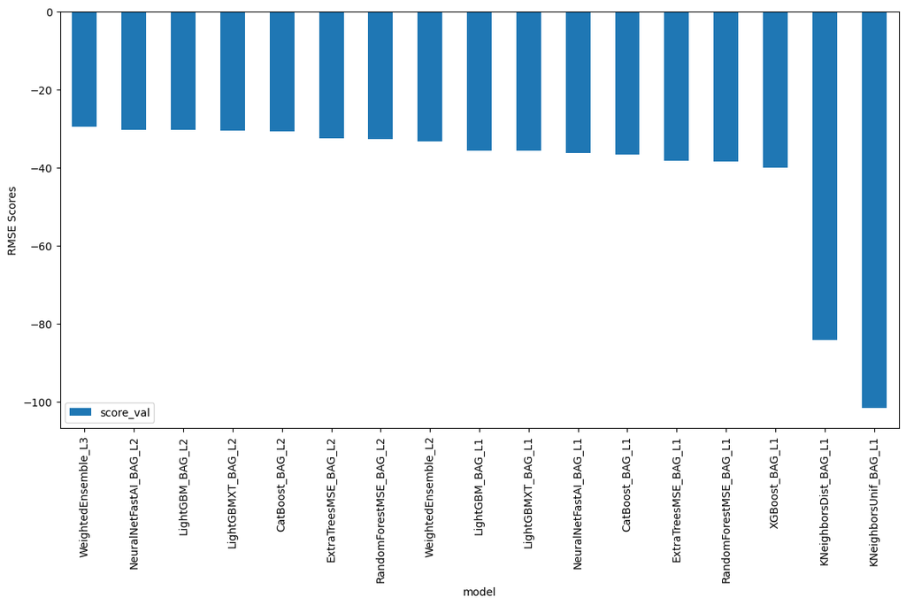

```python
new_leaderboard = predictor_new_features.leaderboard()
new_leaderboard.plot(kind="bar", x="model", y="score_val", figsize=(14, 7))
plt.ylabel("RMSE Scores")
plt.show()
```

```python
new_leaderboard_df = pd.DataFrame(predictor_new_features.leaderboard(silent=True))
new_leaderboard_df
```

[output not shown]

```python
predictions_new_features = predictor_new_features.predict(test)
predictions_new_features.head()
```

```
0    21.570511
1    13.066343
2    13.247266
3    13.218771
4     9.118248
Name: count, dtype: float32
```

```python
# Remember to set all negative values to zero
predictions_new_features[predictions_new_features < 0] = 0
```

```python
# Same submitting predictions
submission_new_features = pd.read_csv('sampleSubmission.csv', parse_dates = ['datetime'])
submission_new_features.head()
submission_new_features["count"] = predictions_new_features
submission_new_features.to_csv("submission_new_features.csv", index=False)
```

```python
!kaggle competitions submit -c bike-sharing-demand -f submission_new_features.csv -m "new features"
```

```
Successfully submitted to Bike Sharing Demand
```

```python
!kaggle competitions submissions -c bike-sharing-demand | tail -n +1 | head -n 6
```

[output not shown]

## Step 6: Hyper parameter optimization

- There are many options for hyper parameter optimization.
- Options are to change the AutoGluon higher level parameters or the individual model hyperparameters.
- The hyperparameters of the models themselves that are in AutoGluon. Those need the `hyperparameter` and `hyperparameter_tune_kwargs` arguments.

```python
import autogluon.common as ag

nn_options = {'num_epochs': 5,
              'learning_rate': ag.space.Real(1e-4, 1e-2, default=5e-4, log=True),
              'activation': ag.space.Categorical('relu', 'softrelu', 'tanh'),
              'dropout_prob': ag.space.Real(0.0, 0.5, default=0.1)}

gbm_options = [{'extra_trees': True,
                'num_boost_round': ag.space.Int(lower=100, upper=500, default=100),
                'num_leaves': ag.space.Int(lower=25, upper=64, default=36),
                'ag_args': {'name_suffix': 'XT'}}, {}, 'GBMLarge']


hyperparameters = {  # hyperparameters of each model type
                   'GBM': gbm_options,
                   'NN_TORCH': nn_options,
                  }



hyperparameter_tune_kwargs = {
    'num_trials': 20,
    'scheduler': 'local',
    'searcher': 'random',
    'max_t': 100,
}


predictor_new_hpo = TabularPredictor(label ='count', problem_type = 'regression', eval_metric = 'rmse',).fit(
                                                                         train_data=dtrain,
                                                                         time_limit=600,
                                                                         presets='optimize_for_deployment',
                                                                         hyperparameters=hyperparameters,
                                                                         hyperparameter_tune_kwargs=hyperparameter_tune_kwargs,)
```

[output not shown]

[output cut: 10 more lines]

```
	0.1s = Fit runtime
	10 features in original data used to generate 14 features in processed data.
	Train Data (Processed) Memory Usage: 0.80 MB (0.0% of available memory)
Data preprocessing and feature engineering runtime = 0.11s ...
AutoGluon will gauge predictive performance using evaluation metric: 'root_mean_squared_error'
	This metric's sign has been flipped to adhere to being higher_is_better. The metric score can be multiplied by -1 to get the metric value.
	To change this, specify the eval_metric parameter of Predictor()
Automatically generating train/validation split with holdout_frac=0.2, Train Rows: 8708, Val Rows: 2178
User-specified model hyperparameters to be fit:
{
	'GBM': [{'extra_trees': True, 'num_boost_round': Int: lower=100, upper=500, 'num_leaves': Int: lower=25, upper=64, 'ag_args': {'name_suffix': 'XT'}}, {}, 'GBMLarge'],
	'NN_TORCH': {'num_epochs': 5, 'learning_rate': Real: lower=0.0001, upper=0.01, 'activation': Categorical['relu', 'softrelu', 'tanh'], 'dropout_prob': Real: lower=0.0, upper=0.5},
}
Fitting 4 L1 models ...
Hyperparameter tuning model: LightGBMXT ... Tuning model for up to 134.98s of the 599.89s of remaining time.
```

[output not shown]

[output cut: 26 more lines]

[output not shown]

[output not shown]

[output not shown]

[output cut: 60 more lines]

[output not shown]

```
[1000]	valid_set's rmse: 39.0622
```

[output not shown]

```python
predictions_new_hpo =predictor_new_hpo.predict(test)
predictions_new_hpo.head()
```

```
0    15.616138
1    -0.244058
2    -3.527328
3     2.855097
4     2.323433
Name: count, dtype: float32
```

```python
predictor_new_hpo.fit_summary()
```

```
*** Summary of fit() ***
Estimated performance of each model:
                 model  score_val              eval_metric  pred_time_val   fit_time  pred_time_val_marginal  fit_time_marginal  stack_level  can_infer  fit_order
0  WeightedEnsemble_L2 -36.584124  root_mean_squared_error       0.199621  10.243405                0.000000           0.020623            2       True          5
1          LightGBM\T5 -37.545503  root_mean_squared_error       0.024142   1.719728                0.024142           1.719728            1       True          1
2         LightGBM\T11 -37.574597  root_mean_squared_error       0.133878   6.250889                0.133878           6.250889            1       True          3
3         LightGBM\T19 -37.580832  root_mean_squared_error       0.026553   1.065575                0.026553           1.065575            1       True          4
4          LightGBM\T7 -37.596501  root_mean_squared_error       0.015048   1.186590                0.015048           1.186590            1       True          2
Number of models trained: 5
Types of models trained:
{'WeightedEnsembleModel', 'LGBModel'}
Bagging used: False
Multi-layer stack-ensembling used: False
Feature Metadata (Processed):
(raw dtype, special dtypes):
('category', [])             : 3 | ['season', 'weather', 'hour']
('float', [])                : 3 | ['temp', 'atemp', 'windspeed']
('int', [])                  : 1 | ['humidity']
('int', ['bool'])            : 2 | ['holiday', 'workingday']
('int', ['datetime_as_int']) : 5 | ['datetime', 'datetime.year', 'datetime.month', 'datetime.day', 'datetime.dayofweek']
Plot summary of models saved to file: AutogluonModels\ag-20240501_202514SummaryOfModels.html
*** End of fit() summary ***
```

[output not shown]

[output cut: 13 more lines]

[output not shown]

```python
# Remember to set all negative values to zero
predictions_new_hpo[predictions_new_hpo < 0] = 0
```

```python
# Same submitting predictions
submission_new_hpo = pd.read_csv('sampleSubmission.csv', parse_dates = ['datetime'])
submission_new_hpo.head()
submission_new_hpo["count"] = predictions_new_hpo
submission_new_hpo.to_csv("submission_new_hpo.csv", index=False)
```

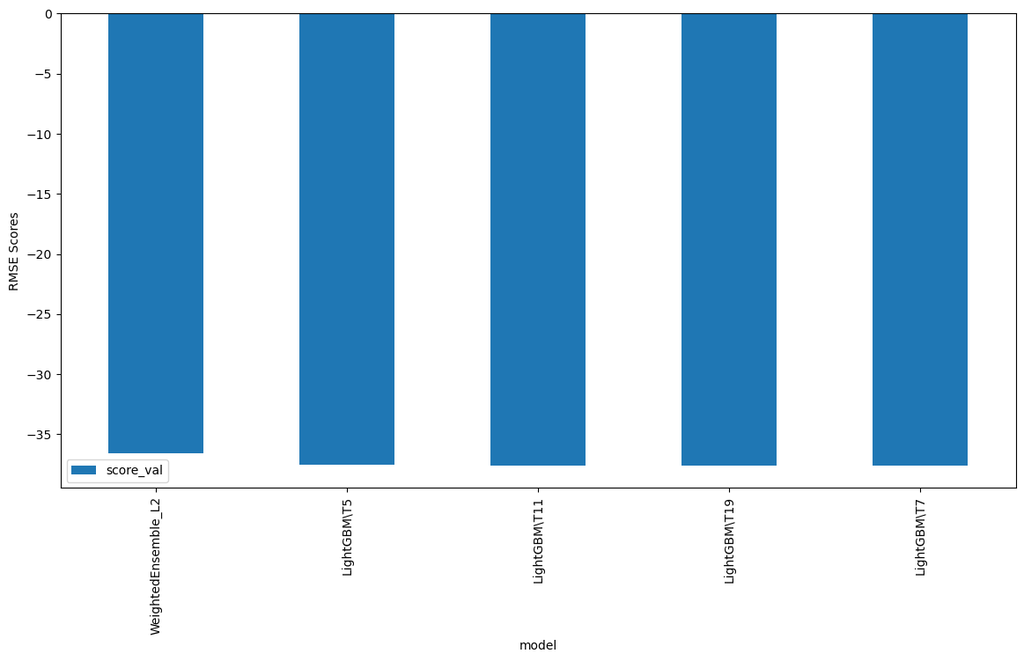

```python
hpo_leaderboard = predictor_new_hpo.leaderboard()
hpo_leaderboard.plot(kind="bar", x="model", y="score_val", figsize=(14, 7))
plt.ylabel("RMSE Scores")
plt.show()
```

```python
!kaggle competitions submit -c bike-sharing-demand -f submission_new_hpo.csv -m "new features with hyperparameters"
```

```
Successfully submitted to Bike Sharing Demand
```

```python
!kaggle competitions submissions -c bike-sharing-demand | tail -n +1 | head -n 6
```

[output not shown]